# 探索性数据分析

# 目录

- 1 介绍
  - 1.1 探索性数据分析
  - 1.2 载入包
- 2 问题
- 3 变异（Variation）
  - 3.1 可视化分布
  - 3.2 典型值（Typical values）
  - 3.3 异常值（Unusual values）
  - 3.4 缺失值（Missing values）
- 4 协变（Covariation）
  - 4.1 一个类别型变量和一个连续型变量
    - 4.1.1 频数多边形图与核密度图
    - 4.1.2 箱线图
    - 4.1.3 扰动点图
  - 4.2 两个类别型变量
    - 4.2.1 频数图
    - 4.2.2 瓦片图
  - 4.3 两个连续型变量
    - 4.3.1 散点图
    - 4.3.2 蜂窝图
    - 4.3.3 箱线图
- 5 模式和模型
- 5.1 模式
- 5.2 模型
- 6 ggplot2

# 1 介绍

## 1.1 探索性数据分析

- 1 对数据提出问题
- 2 通过数据**可视化（visualisation）**、数据**转换（transform）**、数据**建模（model）**来寻找答案
- 3 利用探索到的知识来提炼问题或提出新的问题

## 1.2 载入包

```r
library(tidyverse)
```

# 2 问题

探索性数据分析（EDA）的目的是认识数据。最简单的方法是用问题来指导探索的过程。当你提出一个问题，该问题就会让你的注意力集中于数据集的特定部分，并帮助你决定使用何种方法来进行数据可视化、建模和转换。

EDA是一个创造性的过程。和绝大多数创造性过程相同，提出高质量问题的关键在于提出足够数量的问题。在刚开始进行分析的时候，由于缺乏对数据内在的理解，很难提出有启发意义的问题。但是从另一方面来说，每提出一个新的问题，都会让你了解数据的一个新的方面，从而提高得到发现的机会。如果对于每一个问题，你都能基于发现提出一个新的问题，那你就能够发掘到数据中最有趣的部分，并提出一系列引人深思的问题。

总的来说，你能够提出两类问题：

- 1. What type of **variation** occurs within my variables?
- 2. What type of **covariation** occurs between my variables?

# 3 变异（Variation）

变异是指变量取值的变化趋势。每一个变量都有其变异的模式（即分布），可以揭示出有趣的信息。理解变量的变异模式的最佳方式，就是对变量取值的分布进行可视化。

## 3.1 可视化分布

如何对变量的分布进行可视化，取决于该变量是离散型变量还是连续型变量。在R中，离散型变量通常以因子（`factor`）或字符向量（`character vector`）的形式保存。

- 使用条形图 `geom_bar` 观察离散型变量的分布

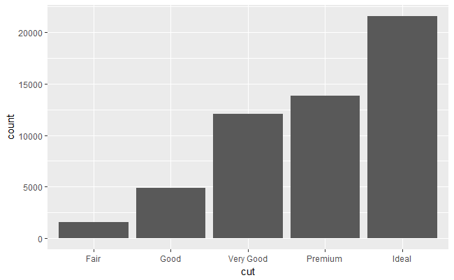

```r
ggplot(data = diamonds) +
  geom_bar(mapping = aes(x = cut))
```

条形图的高度代表每一个类别中样本的个数，可以使用 `dplyr::count()` 来计算得到：

```r
diamonds %>%
  count(cut)
```

| cut | n |
| --- | --- |
| Fair | 1610 |
| Good | 4906 |
| Very Good | 12082 |
| Premium | 13791 |
| Ideal | 21551 |

```
#> # A tibble: 5 × 2
#>         cut     n
#>       <ord> <int>
#> 1      Fair  1610
#> 2      Good  4906
#> 3 Very Good 12082
#> 4   Premium 13791
#> 5     Ideal 21551
```

- 使用直方图 `geom_histogram` 观察连续型变量的分布

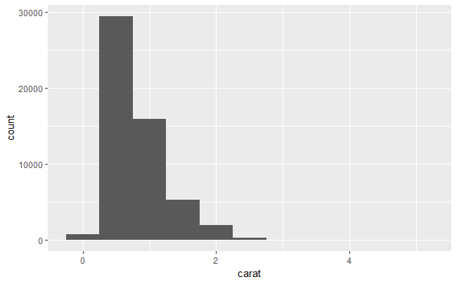

```r
ggplot(data = diamonds) +
  geom_histogram(mapping = aes(x = carat), binwidth = 0.5)
```

直方图的高度代表每一个封箱中样本的个数，可以使用 `dplyr::count()` 和 `ggplot2::cut_width()` 来计算得到：

```r
diamonds %>%
  count(cut_width(carat, 0.5))
```

| cut_width(carat, 0.5) | n |
| --- | --- |
| [-0.25,0.25] | 785 |
| (0.25,0.75] | 29498 |
| (0.75,1.25] | 15977 |
| (1.25,1.75] | 5313 |
| (1.75,2.25] | 2002 |
| (2.25,2.75] | 322 |
| (2.75,3.25] | 32 |
| (3.25,3.75] | 5 |
| (3.75,4.25] | 4 |
| (4.25,4.75] | 1 |

[output cut: 1 more lines]

```
#> # A tibble: 11 × 2
#>   `cut_width(carat, 0.5)`     n
#>                    <fctr> <int>
#> 1            [-0.25,0.25]   785
#> 2             (0.25,0.75] 29498
#> 3             (0.75,1.25] 15977
#> 4             (1.25,1.75]  5313
#> 5             (1.75,2.25]  2002
#> 6             (2.25,2.75]   322
#> # ... with 5 more rows
```

可以使用 `binwidth` 参数来控制封箱的宽度，设置不同的 `binwidth` ，可以展现出数据中不同的模式。

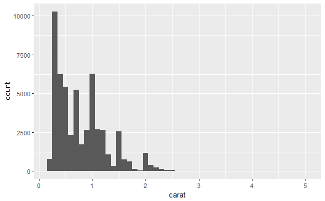

```r
smaller <- diamonds %>%
  filter(carat < 3)
ggplot(data = diamonds, mapping = aes(x = carat)) +
  geom_histogram(binwidth = 0.1)
```

- 使用频数多边形图 `geom_freqpoly` 在同一幅图中观察多个变量的分布

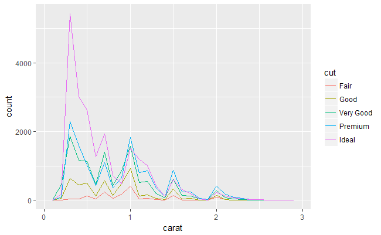

```r
ggplot(data = smaller, mapping = aes(x = carat, colour = cut)) +
  geom_freqpoly(binwidth = 0.1)
```

在对变量的变异模式进行可视化后，我们应该在图中寻找什么样的信息？提出什么样的问题？接下来将会介绍几种最有用的信息和问题，有待我们从可视化的结果中提炼。提出好的问题的关键在于好奇心（你希望发现什么新问题？）和怀疑心（这些问题会产生什么误导？）。

## 3.2 典型值（Typical values）

在条形图和直方图中，高度代表样本的个数。通常你可以提出以下问题：

- 哪一个值是最常见的？为什么？
- 哪一个值是最稀少的？为什么？这是否符合你的预估？
- 你是否发现了任何不寻常的模式？如何解释？

举例而言，你可以对下面的直方图提出以下问题：

- 为什么克拉数是整数或普通分数（common fractions）的钻石更多？
- 为什么对于每一个峰值，峰值右边的钻石比峰值左边的钻石更多？
- 为什么没有重量大于3克拉的钻石？

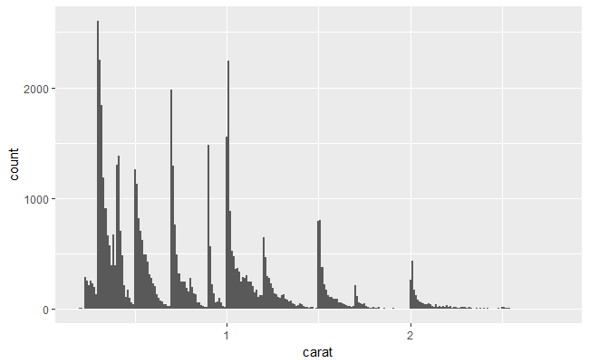

```r
ggplot(data = smaller, mapping = aes(x = carat)) +
  geom_histogram(binwidth = 0.01)
```

图形提示了钻石的克拉数存在聚类，为了更好地理解数据中的子类别，你可以提出以下问题：

- 统一聚类内部的样本有何种相似之处？
- 不同聚类的样本之间有何种区别？
- 应该如何解释或描述这些聚类？
- 为什么聚类的存在可能产生误导？

下图展示了黄石国家公园内的老忠实间歇泉272次喷发的时长（分钟）。喷发的时间看上去存在2个聚类，短时间的喷发（2分钟左右）和长时间的喷发（4到5分钟），很少有喷发的时长在此之间。

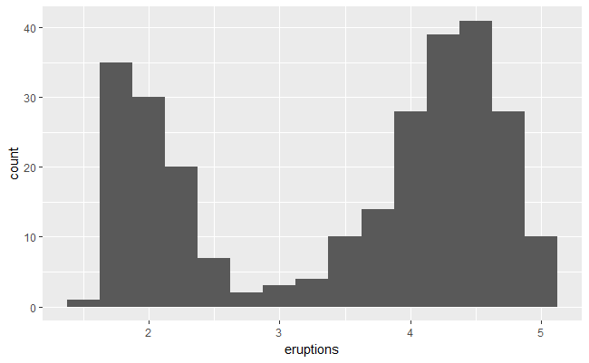

```r
ggplot(data = faithful, mapping = aes(x = eruptions)) +
  geom_histogram(binwidth = 0.25)
```

上面提出的很多问题会促使你去探究变量之间的关系，例如，一个变量的取值，是否会影响到另一个变量的取值。

## 3.3 异常值（Unusual values）

异常值是那些看上去不符合规律的样本点。有时候，异常值是数据录入错误产生的；有时候，异常值会引发新的发现。在直方图中很难直观地发现异常值，只能通过异常的坐标轴界限来发现异常值的存在。

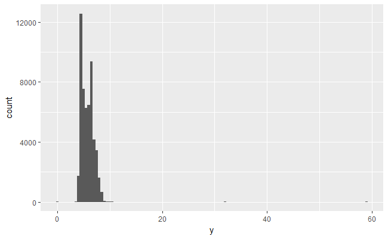

```r
ggplot(diamonds) +
  geom_histogram(mapping = aes(x = y), binwidth = 0.5)
```

可以通过 `coord_cartesian()` 控制坐标轴界限，对图形进行缩放，从而更好地观察异常值

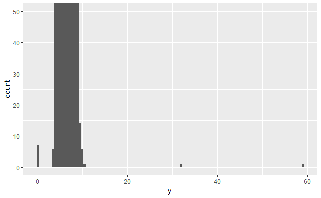

```r
ggplot(diamonds) +
  geom_histogram(mapping = aes(x = y), binwidth = 0.5) +
  coord_cartesian(ylim = c(0, 50))
```

`ylim()` 也可以控制坐标轴界限，但是它会将坐标轴界限外的所有点移除，然后再绘制图形

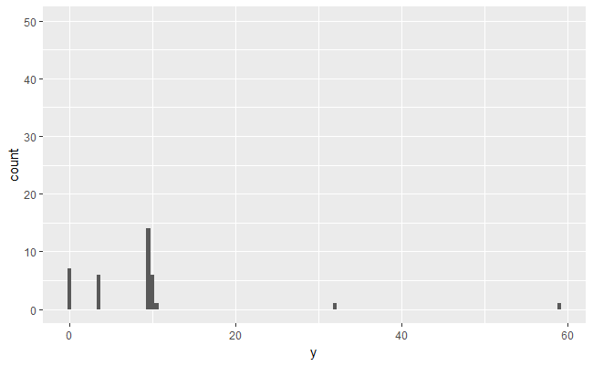

```r
ggplot(diamonds) +
  geom_histogram(mapping = aes(x = y), binwidth = 0.5) +
  ylim(c(0, 50))
```

从图形中可以看出，存在3个异常值（0, ~30, ~60），用 `dplyr` 将异常值取出：

```r
unusual <- diamonds %>%
  filter(y < 3 | y > 20) %>%
  arrange(y)
unusual
```

| carat | cut | color | clarity | depth | table | price | x | y | z |
| --- | --- | --- | --- | --- | --- | --- | --- | --- | --- |
| 1.00 | Very Good | H | VS2 | 63.3 | 53 | 5139 | 0.00 | 0.0 | 0.00 |
| 1.14 | Fair | G | VS1 | 57.5 | 67 | 6381 | 0.00 | 0.0 | 0.00 |
| 1.56 | Ideal | G | VS2 | 62.2 | 54 | 12800 | 0.00 | 0.0 | 0.00 |
| 1.20 | Premium | D | VVS1 | 62.1 | 59 | 15686 | 0.00 | 0.0 | 0.00 |
| 2.25 | Premium | H | SI2 | 62.8 | 59 | 18034 | 0.00 | 0.0 | 0.00 |
| 0.71 | Good | F | SI2 | 64.1 | 60 | 2130 | 0.00 | 0.0 | 0.00 |
| 0.71 | Good | F | SI2 | 64.1 | 60 | 2130 | 0.00 | 0.0 | 0.00 |
| 0.51 | Ideal | E | VS1 | 61.8 | 55 | 2075 | 5.15 | 31.8 | 5.12 |
| 2.00 | Premium | H | SI2 | 58.9 | 57 | 12210 | 8.09 | 58.9 | 8.06 |

```
#> # A tibble: 9 × 10
#>   carat       cut color clarity depth table price     x     y     z
#>   <dbl>     <ord> <ord>   <ord> <dbl> <dbl> <int> <dbl> <dbl> <dbl>
#> 1  1.00 Very Good     H     VS2  63.3    53  5139  0.00   0.0  0.00
#> 2  1.14      Fair     G     VS1  57.5    67  6381  0.00   0.0  0.00
#> 3  1.56     Ideal     G     VS2  62.2    54 12800  0.00   0.0  0.00
#> 4  1.20   Premium     D    VVS1  62.1    59 15686  0.00   0.0  0.00
#> 5  2.25   Premium     H     SI2  62.8    59 18034  0.00   0.0  0.00
#> 6  0.71      Good     F     SI2  64.1    60  2130  0.00   0.0  0.00
#> 7  0.71      Good     F     SI2  64.1    60  2130  0.00   0.0  0.00
#> 8  0.51     Ideal     E     VS1  61.8    55  2075  5.15  31.8  5.12
#> 9  2.00   Premium     H     SI2  58.9    57 12210  8.09  58.9  8.06
```

变量 `y` 代表钻石长、宽、高中的一维，单位是毫米（mm）。钻石不可能宽度为0mm，32mm和59mm宽的钻石也不太可能，所以选择剔除这些异常值。

通常，最好的办法是在保留和剔除异常值的情况下都进行分析。  
如果异常值对分析结果的影响微乎其微，并且你无法解释存在异常值的原因，那么比较好的选择是用缺失值替代异常值。  
如果异常值对分析结果的影响很显著，那你就不能在没有合理理由的情况下剔除异常值。你需要解释异常值存在的原因，并明确标明你对异常值做的处理。

## 3.4 缺失值（Missing values）

如果在数据中出现异常值，并且只想对剩余的数据进行分析，那么你有2种选择：

- 1 删除存在异常值的行

```r
diamonds2 <- diamonds %>%
  filter(between(y, 3, 20))
```

- 2 用缺失值替代异常值，可以用 `mutate()`、 `ifelse()` 和 `NA` 达到这一目的

```r
diamonds2 <- diamonds %>%
  mutate(y = ifelse(y < 3 | y > 20, NA, y))
```

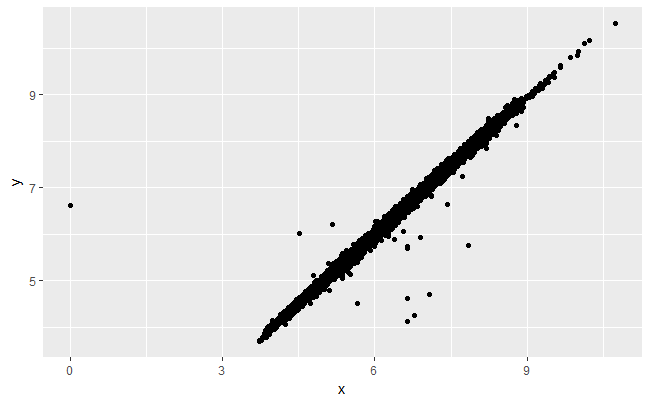

```r
ggplot(data = diamonds2, mapping = aes(x = x, y = y)) +
  geom_point()
```

使用 `ggplot2` 作图时，缺失值不会显示在图形中，但会针对缺失值给出 warning

```
#> Warning: Removed 9 rows containing missing values (geom_point).
```

`na.rm = TRUE` 参数可以禁用 warning

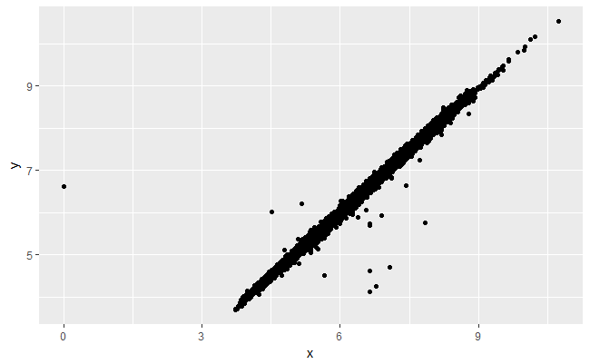

```r
ggplot(data = diamonds2, mapping = aes(x = x, y = y)) +
  geom_point(na.rm = TRUE)
```

- 3 有时候，缺失值也包含了某种信息。在 `flights` 数据集中，变量 `dep_time` 是缺失值代表该次航班被取消。用 `is.na()` 构建一个新的变量，比较正常航班和取消航班的计划起飞时间。

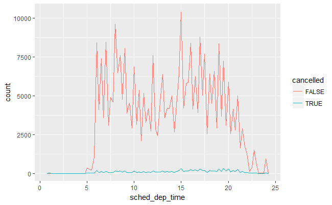

```r
nycflights13::flights %>%
  mutate(
    cancelled = is.na(dep_time),
    sched_hour = sched_dep_time %/% 100,
    sched_min = sched_dep_time %% 100,
    sched_dep_time = sched_hour + sched_min / 60
  ) %>%
  ggplot(mapping = aes(sched_dep_time)) +
    geom_freqpoly(mapping = aes(colour = cancelled), binwidth = 1/4)
```

# 4 协变（Covariation）

协变是两个或更多变量取值的共同变化趋势。如何对协变进行可视化，取决于变量的类型。

## 4.1 一个类别型变量和一个连续型变量

### 4.1.1 频数多边形图与核密度图

- `geom_freqpoly()`

以类别型变量为分组依据，对不同组别连续型变量的分布进行可视化，当纵坐标为 `count` 时，绘制频数多边形图，样本数少的组别可视化效果很差

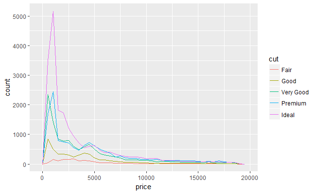

```r
ggplot(data = diamonds, mapping = aes(x = price)) +
  geom_freqpoly(mapping = aes(colour = cut), binwidth = 500)
```

每个组别的样本数差别很大

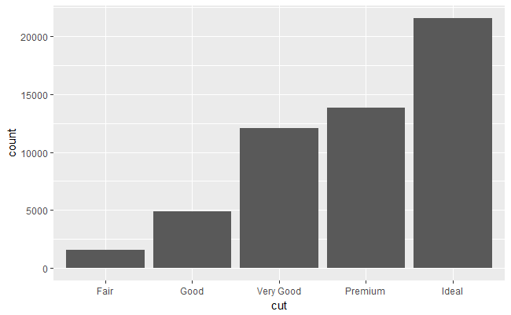

```r
ggplot(diamonds) +
  geom_bar(mapping = aes(x = cut))
```

建议将纵坐标设定为 `density` ，绘制核密度图，可视化效果更好

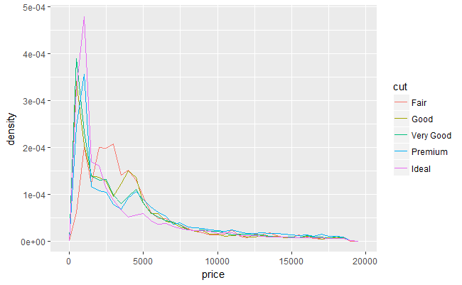

```r
ggplot(data = diamonds, mapping = aes(x = price, y = ..density..)) +
  geom_freqpoly(mapping = aes(colour = cut), binwidth = 500)
```

### 4.1.2 箱线图

- `geom_boxplot()`

箱线图包含的信息量比核密度图少，但是更加紧凑

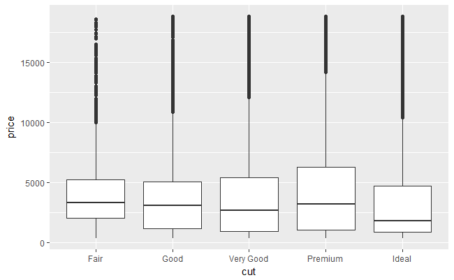

```r
ggplot(data = diamonds, mapping = aes(x = cut, y = price)) +
  geom_boxplot()
```

`reorder` 函数可以对分组离散型变量进行排序，此处根据 `hwy` 的中位数对 `class` 进行排序

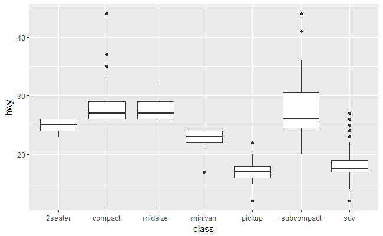

```r
ggplot(data = mpg, mapping = aes(x = class, y = hwy)) +
  geom_boxplot()
```

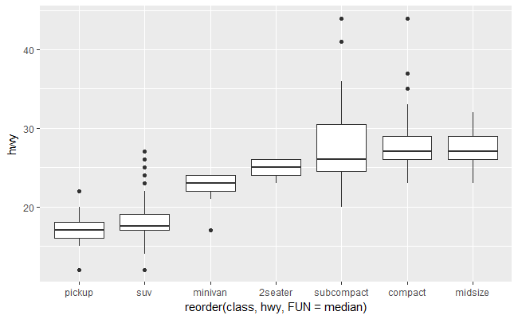

```r
ggplot(data = mpg) +
  geom_boxplot(mapping = aes(x = reorder(class, hwy, FUN = median), y = hwy))
```

当变量名过长时，可以将坐标轴翻转90度，以获得更好的视觉效果

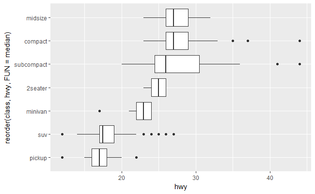

```r
ggplot(data = mpg) +
  geom_boxplot(mapping = aes(x = reorder(class, hwy, FUN = median), y = hwy)) +
  coord_flip()
```

- `ggstance` 包中的 `geom_boxploth()`

作用类似于 `geom_boxplot` + `coord_flip()`

```r
library(ggstance)
```

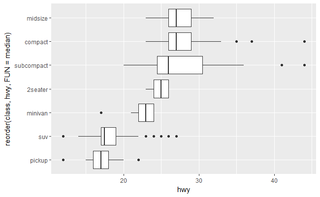

```r
ggplot(data = mpg) +
  geom_boxploth(mapping = aes(y = reorder(class, hwy, FUN = median), x = hwy))
```

- `lvplot` 包中的 `geom_lv()`

较大数据集中将会有很多异常值，传统的箱线图会绘制所有的异常值点，可视化效果较差。可以考虑使用 `lvplot` 中的 `geom_lv()`

```r
library(lvplot)
```

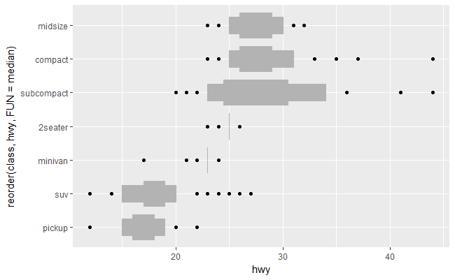

```r
ggplot(data = mpg) +
  geom_lv(mapping = aes(x = reorder(class, hwy, FUN = median), y = hwy)) +
  coord_flip()
```

- `geom_violin()`

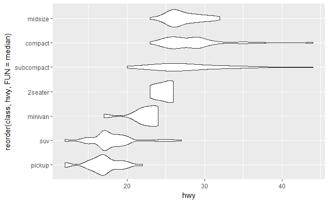

```r
ggplot(data = mpg) +
  geom_violin(mapping = aes(x = reorder(class, hwy, FUN = median), y = hwy)) +
  coord_flip()
```

### 4.1.3 扰动点图

- `geom_jitter()`

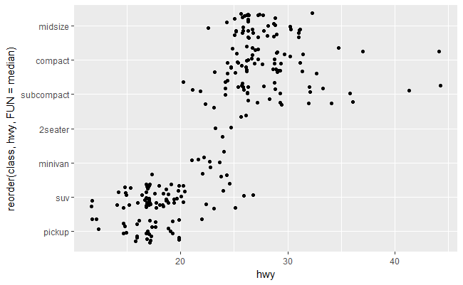

```r
ggplot(data = mpg) +
  geom_jitter(mapping = aes(x = reorder(class, hwy, FUN = median), y = hwy)) +
  coord_flip()
```

- `ggbeeswarm` 包

```r
library(ggbeeswarm)
```

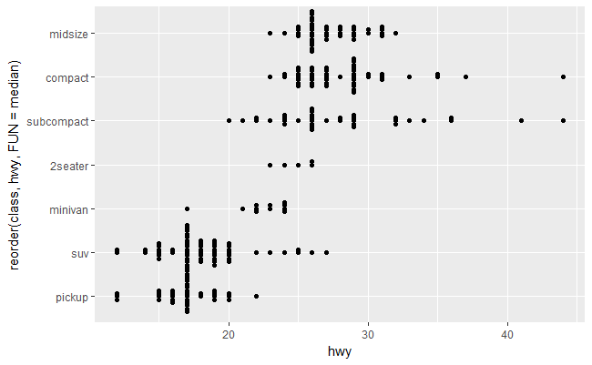

```r
ggplot(data = mpg) +
  geom_beeswarm(mapping = aes(x = reorder(class, hwy, FUN = median), y = hwy)) +
  coord_flip()
```

## 4.2 两个类别型变量

计算两个变量不同种组合的样本个数

### 4.2.1 频数图

- `geom_count()`

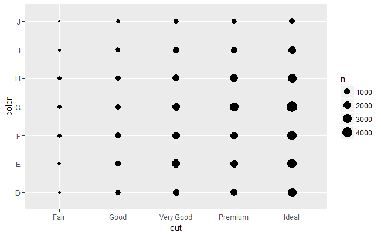

```r
ggplot(data = diamonds) +
  geom_count(mapping = aes(x = cut, y = color))
```

```r
diamonds %>%
  count(color, cut)
```

| color | cut | n |
| --- | --- | --- |
| D | Fair | 163 |
| D | Good | 662 |
| D | Very Good | 1513 |
| D | Premium | 1603 |
| D | Ideal | 2834 |
| E | Fair | 224 |
| E | Good | 933 |
| E | Very Good | 2400 |
| E | Premium | 2337 |
| E | Ideal | 3903 |

[output cut: 25 more lines]

```
#> Source: local data frame [35 x 3]
#> Groups: color [?]
#>
#>   color       cut     n
#>   <ord>     <ord> <int>
#> 1     D      Fair   163
#> 2     D      Good   662
#> 3     D Very Good  1513
#> 4     D   Premium  1603
#> 5     D     Ideal  2834
#> 6     E      Fair   224
#> # ... with 29 more rows
```

### 4.2.2 瓦片图

- `geom_tile()`

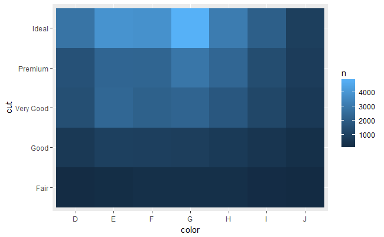

```r
diamonds %>%
  count(color, cut) %>%
  ggplot(mapping = aes(x = color, y = cut)) +
    geom_tile(mapping = aes(fill = n))
```